# Ant1-KO Differential Expression

Jeremy Leipzig

2/16/2016

# Introduction

## Samples

Below are results of the STAR mapping. Conditions are M for Muscle, H for Heart, T for Treatment(ANT1), N for Normal (B6ME).

|  | Sample | Input.reads | Uniquely.mapped | Mapped.to.multiple.loci | cond |
| --- | --- | --- | --- | --- | --- |
| IonXpressRNA_002.R_2013_11_26_13_55_09_user_1PR-8-RNA-Seq_whole_transcriptome | IonXpressRNA_002... | 25482089 | 44.12% | 17.41% | MT |
| IonXpressRNA_004.R_2013_11_26_20_48_53_user_1PR-9-RNA-Seq_whole_transcriptome | IonXpressRNA_004... | 31826234 | 50.70% | 19.75% | MT |
| IonXpressRNA_006.R_2013_12_04_09_37_33_1PR-10-RNA-Seq_whole_transcriptome_76303 | IonXpressRNA_006... | 29907063 | 51.24% | 14.94% | MT |
| IonXpressRNA_008.R_2013_12_06_12_45_12_user_1PR-11-RNA-Seq_whole_transcriptome | IonXpressRNA_008... | 34668896 | 50.78% | 19.78% | MT |
| IonXpressRNA_001.R_2013_11_26_13_55_09_user_1PR-8-RNA-Seq_whole_transcriptome | IonXpressRNA_001... | 35471247 | 48.76% | 18.60% | MN |
| IonXpressRNA_003.R_2013_11_26_20_48_53_user_1PR-9-RNA-Seq_whole_transcriptome | IonXpressRNA_003... | 28749689 | 48.81% | 18.49% | MN |
| IonXpressRNA_005.R_2013_12_04_09_37_33_1PR-10-RNA-Seq_whole_transcriptome_76303 | IonXpressRNA_005... | 27702368 | 50.68% | 16.09% | MN |
| IonXpressRNA_007.R_2013_12_06_12_45_12_user_1PR-11-RNA-Seq_whole_transcriptome | IonXpressRNA_007... | 15598072 | 59.85% | 14.62% | MN |
| IonXpressRNA_010.R_2013_12_19_16_11_21_user_1PR-13-RNA-Seq_whole_transcriptome | IonXpressRNA_010... | 20270224 | 42.32% | 19.61% | HT |
| IonXpressRNA_012.R_2013_12_18_20_25_40_user_1PR-12-RNA-Seq_whole_transcriptome | IonXpressRNA_012... | 26586149 | 38.02% | 22.20% | HT |

[output cut: 6 more lines]

# Alignment

After trimming, transcript counts were generated by a STAR alignment to genomic sequences.

The STAR used for the samples is as follows:

```
{STAR} --genomeDir {STARREFDIR} --outFileNamePrefix {wildcards.sample}_ --readFilesIn {input} --runThreadN 24
--genomeLoad NoSharedMemory --outSAMattributes All --outSAMstrandField intronMotif --sjdbGTFfile {GTFFILE}
```

## Normalization

ERCC spike-ins were downloaded from [here](http://tools.invitrogen.com/downloads/ERCC92.fa) and used as a reference. Total counts from all 92 sequences are below. These are used for the *sizeFactors* in DESeq such that they become divisors for each sample count.

|  | sample | count |
| --- | --- | --- |
| 1 | IonXpressRNA_002.R_2013_11_26_13_55_09_user_1PR-8-RNA-Seq_whole_transcriptome | 25216131 |
| 2 | IonXpressRNA_004.R_2013_11_26_20_48_53_user_1PR-9-RNA-Seq_whole_transcriptome | 31454860 |
| 3 | IonXpressRNA_006.R_2013_12_04_09_37_33_1PR-10-RNA-Seq_whole_transcriptome_76303 | 29509934 |
| 4 | IonXpressRNA_008.R_2013_12_06_12_45_12_user_1PR-11-RNA-Seq_whole_transcriptome | 34313656 |
| 5 | IonXpressRNA_001.R_2013_11_26_13_55_09_user_1PR-8-RNA-Seq_whole_transcriptome | 34958364 |
| 6 | IonXpressRNA_003.R_2013_11_26_20_48_53_user_1PR-9-RNA-Seq_whole_transcriptome | 28273488 |
| 7 | IonXpressRNA_005.R_2013_12_04_09_37_33_1PR-10-RNA-Seq_whole_transcriptome_76303 | 27318394 |
| 8 | IonXpressRNA_007.R_2013_12_06_12_45_12_user_1PR-11-RNA-Seq_whole_transcriptome | 15401398 |
| 9 | IonXpressRNA_010.R_2013_12_19_16_11_21_user_1PR-13-RNA-Seq_whole_transcriptome | 20047401 |
| 10 | IonXpressRNA_012.R_2013_12_18_20_25_40_user_1PR-12-RNA-Seq_whole_transcriptome | 26273728 |

[output cut: 6 more lines]

# DESeq

A reanalysis of the non-normalized count data was performed using the R-based RNA-Seq analysis package DESeq [Anders](http://dx.doi.org/10.1038/npre.2010.4282.2) in order to detect differential expression between normal and treatment.

This report uses DESeq version 1.22.1.

DESeq offers different statistical models and parameters to choose from depending on the data to be analyzed.

Empirical dispersion can be computed using a *pooled*, *per-condition*, or *blind* (no replicates) method.

The following, sharing modes, which determine how much information is used to inform the dispersion of other genes, are available:

- `fit-only` is appropriate for only a few replicates
- `maximum` is more conservative for three or four replicates,
- `gene-est-only` is more aggressive, and is ideal for many replicates

For this report, we have used the per-condition method and maximum sharing mode.

# Muscle results

## Significantly DE genes in muscle

Significantly differentially expressed genes (padj<0.01). Fold change is ANT1/B6ME.

The `cmyo` column is the cardiomyopathy involvement score from http://www.disgenet.org.

The `MSeqDR` column will provide a link if the gene in question is one of 1363 MSeqDR mitochondrial genes.

|  | gene | ensid | baseMean | bNorm | bRB | fc | log2fc | pval | padj | cmyo | MSeqDR |
| --- | --- | --- | --- | --- | --- | --- | --- | --- | --- | --- | --- |
| 1 | Gnai3 | ENSMUSG00000000001 | 9.23722219312899e-06 | 1.34448896366334e-05 | 5.0295547496246e-06 | 0.374086726299377 | -1.41855531916651 | 1.36594339973533e-07 | 5.69571156653171e-06 |  |  |
| 2 | Wnt9a | ENSMUSG00000000126 | 4.86404592370812e-06 | 6.45250813845907e-06 | 3.27558370895717e-06 | 0.507645033321789 | -0.978108038182317 | 0.00126442283487195 | 0.00846573312497069 |  |  |
| 3 | Xpo6 | ENSMUSG00000000131 | 7.1755147118185e-06 | 9.58838691543936e-06 | 4.76264250819764e-06 | 0.496709462206699 | -1.00952586482521 | 0.000331474711014742 | 0.00307054675342516 |  |  |
| 4 | Gpr107 | ENSMUSG00000000194 | 1.67005865925373e-05 | 2.22794680364933e-05 | 1.11217051485814e-05 | 0.49919078545162 | -1.00233679110776 | 0.000194846356067619 | 0.00206351032373783 |  |  |
| 5 | Cdh4 | ENSMUSG00000000305 | 1.95497500097081e-05 | 1.28757162959024e-05 | 2.62237837235137e-05 | 2.0366854255603 | 1.0262231673285 | 0.00022918088830645 | 0.0023407477189485 |  |  |
| 6 | Galnt1 | ENSMUSG00000000420 | 3.01166375073421e-05 | 3.97837814863138e-05 | 2.04494935283705e-05 | 0.514015831687731 | -0.960115299776314 | 0.000801465078347341 | 0.00601242587734069 |  |  |
| 7 | Itga5 | ENSMUSG00000000555 | 6.77829898154354e-06 | 9.8010333816984e-06 | 3.75556458138869e-06 | 0.383180470377899 | -1.38390406201512 | 7.95073196744203e-06 | 0.000169618464905966 |  |  |
| 8 | Hnrnpd | ENSMUSG00000000568 | 4.46604892817705e-06 | 6.86702889991616e-06 | 2.06506895643794e-06 | 0.300722333710166 | -1.7334960785338 | 0.000240509051109096 | 0.00241930616634552 |  |  |
| 9 | Serpinf1 | ENSMUSG00000000753 | 1.82325906750296e-05 | 2.35258465506096e-05 | 1.29393347994495e-05 | 0.550005066623807 | -0.862483186142114 | 0.000861606094339038 | 0.00634648555447718 |  |  |
| 10 | Tubgcp3 | ENSMUSG00000000759 | 7.94400702440376e-06 | 1.03196546996456e-05 | 5.56835934916192e-06 | 0.539587758624632 | -0.890070475978247 | 0.00142963742494275 | 0.00932034447726596 |  |  |

[output cut: 2287 more lines]

## Upregulated genes in muscle

|  | gene | ensid | baseMean | bNorm | bRB | fc | log2fc | pval | padj | cmyo | MSeqDR |
| --- | --- | --- | --- | --- | --- | --- | --- | --- | --- | --- | --- |
| 1 | Fgf21 | ENSMUSG00000030827 | 4.12719873942119e-07 | 0 | 8.25439747884237e-07 |  | 19.9315685693242 | 2.55092098797963e-10 | 2.27654143780914e-08 |  |  |
| 2 | Gm26794 | ENSMUSG00000097837 | 1.99372515723664e-07 | 9.15134323049883e-09 | 3.8959368821683e-07 | 42.5722954984821 | 5.41184297723135 | 1.40467372746551e-06 | 4.08723750997718e-05 |  |  |
| 3 | Rnu3a | ENSMUSG00000065870 | 7.17984016675054e-05 | 3.61620408270081e-06 | 0.00013998059925231 | 38.7092642038509 | 5.27460697964122 | 3.30555901731867e-57 | 4.8380161777476e-53 |  |  |
| 4 | Kcna10 | ENSMUSG00000042861 | 1.64657947299626e-06 | 8.5897372620142e-08 | 3.20726157337237e-06 | 37.3382965688092 | 5.22258420596008 | 1.37970380471609e-18 | 5.04833622145618e-16 |  |  |
| 5 | Gm1305 | ENSMUSG00000087236 | 1.28627949613269e-07 | 7.15136440595447e-09 | 2.50104534820584e-07 | 34.9729814652346 | 5.12816888668385 | 0.000282054215566449 | 0.00273387119141095 |  |  |
| 6 | Frzb | ENSMUSG00000027004 | 4.23338898414261e-06 | 2.77710984921699e-07 | 8.18906698336352e-06 | 29.4877315914329 | 4.8820429390685 | 9.33941252445378e-24 | 7.19429693199503e-21 |  |  |
| 7 | C130080G10Rik | ENSMUSG00000092397 | 4.77680124277878e-07 | 3.93772273056552e-08 | 9.159830212501e-07 | 23.2617450218124 | 4.53988742213202 | 5.65102719248545e-16 | 1.31283228554313e-13 |  |  |
| 8 | Armc2 | ENSMUSG00000071324 | 8.56558458491336e-07 | 1.00129686474483e-07 | 1.61298723050819e-06 | 16.1089811353723 | 4.00979334390209 | 2.14149952804236e-19 | 8.95513916926515e-17 |  |  |
| 9 | Crybb1 | ENSMUSG00000029343 | 6.72345782612662e-07 | 8.08164019962999e-08 | 1.26387516322902e-06 | 15.6388447395479 | 3.96706203783418 | 4.45477192564817e-05 | 0.000659904608894615 |  |  |
| 10 | Snap91 | ENSMUSG00000033419 | 2.97653816014435e-07 | 3.94476422632231e-08 | 5.55859989765648e-07 | 14.091082707974 | 3.81671056227752 | 1.63929032634419e-07 | 6.70185844032781e-06 |  |  |

[output cut: 40 more lines]

## Downregulated genes in muscle

|  | gene | ensid | baseMean | bNorm | bRB | fc | log2fc | pval | padj | cmyo | MSeqDR |
| --- | --- | --- | --- | --- | --- | --- | --- | --- | --- | --- | --- |
| 1 | Slc25a4 | ENSMUSG00000031633 | 0.000452182609398404 | 0.000904265673533458 | 9.95452633504134e-08 | 0.000110084089514795 | -13.1491064087107 | 1.15299650710154e-17 | 3.59048018679534e-15 | 0.00028350457009367 | SLC25A4 |
| 2 | Mss51 | ENSMUSG00000021815 | 3.77382098141926e-05 | 7.49225642926584e-05 | 5.5385533572693e-07 | 0.00739237025528772 | -7.07974726707342 | 2.92860932399445e-52 | 2.14315630329914e-48 |  |  |
| 3 | Htra4 | ENSMUSG00000037406 | 1.72554636788971e-06 | 3.42128765125871e-06 | 2.9805084520708e-08 | 0.0087116570013464 | -6.84283713182375 | 1.40360957891969e-09 | 1.05349896395223e-07 |  |  |
| 4 | Mrgprg | ENSMUSG00000050276 | 5.19102651552128e-07 | 1.02363384502354e-06 | 1.45714580807128e-08 | 0.0142350295973046 | -6.13441069705702 | 0.000104780796186602 | 0.00128853579986986 |  |  |
| 5 | Clec4d | ENSMUSG00000030144 | 6.50696377599918e-07 | 1.27026333396056e-06 | 3.11294212392726e-08 | 0.0245062739410213 | -5.3507050436138 | 1.29155410817587e-05 | 0.000249711835234637 |  |  |
| 6 | Odf3l2 | ENSMUSG00000035963 | 2.81476804389189e-05 | 5.48793357160699e-05 | 1.41602516176792e-06 | 0.0258025200795802 | -5.27634421215871 | 6.93498304874825e-24 | 5.97061246479291e-21 |  |  |
| 7 | Mt2 | ENSMUSG00000031762 | 3.83727615370457e-06 | 7.46082935921081e-06 | 2.13722948198333e-07 | 0.0286460040711801 | -5.12552228320989 | 6.84093314250161e-29 | 1.11248774970726e-25 |  |  |
| 8 | Nr4a3 | ENSMUSG00000028341 | 1.43564917115805e-05 | 2.79016990825576e-05 | 8.11284340603381e-07 | 0.0290765210463669 | -5.10400152606754 | 9.98157899568345e-29 | 1.46090390180823e-25 |  |  |
| 9 | Sbk2 | ENSMUSG00000030433 | 7.60544584333278e-06 | 1.47119675031234e-05 | 4.98924183542136e-07 | 0.0339128116913127 | -4.88202578745352 | 3.82028589474301e-18 | 1.33127867512997e-15 |  |  |
| 10 | Hspa1a | ENSMUSG00000091971 | 3.79049237243236e-06 | 7.33091736116841e-06 | 2.50067383696315e-07 | 0.034111335781919 | -4.87360493854029 | 8.96657941133519e-31 | 1.8747836609186e-27 |  |  |

[output cut: 40 more lines]

## Log2 Fold change and significance muscle

Genes with high fold change may not be significantly differentially expressed simply due to high variance.

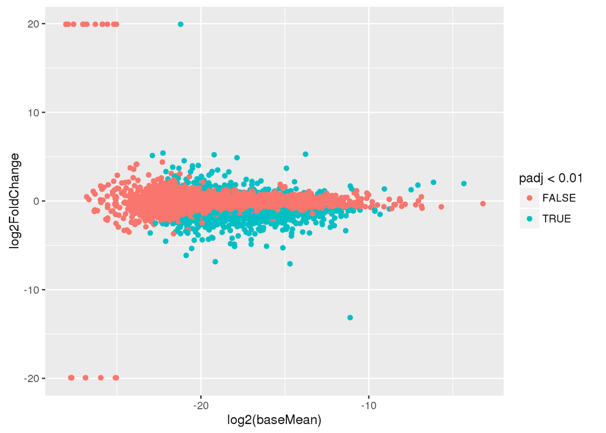

# Heart results

## Significantly DE genes in heart

|  | gene | ensid | baseMean | bNorm | bRB | fc | log2fc | pval | padj | cmyo | MSeqDR |
| --- | --- | --- | --- | --- | --- | --- | --- | --- | --- | --- | --- |
| 1 | Ugp2 | ENSMUSG00000001891 | 0.00017090950926949 | 9.84691211831203e-05 | 0.00024334989735586 | 2.47133207275516 | 1.30528887854557 | 4.20436226836406e-05 | 0.00353698016576512 |  |  |
| 2 | Ndufb2 | ENSMUSG00000002416 | 9.16104673217522e-05 | 4.8668451597753e-05 | 0.000134552483045751 | 2.76467564979946 | 1.46711023421264 | 2.9380966348493e-05 | 0.0025611714356637 |  | NDUFB2 |
| 3 | Rpl10 | ENSMUSG00000008682 | 8.32795928827399e-05 | 3.08441321137167e-05 | 0.000135715053651763 | 4.40002828257272 | 2.13751279715818 | 9.37672186171926e-13 | 3.19201057236852e-10 |  |  |
| 4 | Cd163 | ENSMUSG00000008845 | 1.28305948669397e-05 | 1.93021160395025e-05 | 6.35907369437686e-06 | 0.329449563009712 | -1.60187048174953 | 6.70091732598617e-05 | 0.00513549883862751 |  |  |
| 5 | G0s2 | ENSMUSG00000009633 | 2.08028235597005e-05 | 3.12432391446934e-05 | 1.03624079747076e-05 | 0.331668810865523 | -1.59218474307266 | 6.18143189466678e-05 | 0.00478750264942499 |  |  |
| 6 | Kif1a | ENSMUSG00000014602 | 2.33492649200875e-06 | 3.41298629512206e-07 | 4.32855435450529e-06 | 12.6826010426464 | 3.66477874939498 | 2.08183317484984e-16 | 1.12866200049822e-13 |  |  |
| 7 | Rhbdl3 | ENSMUSG00000017692 | 2.03732564994582e-06 | 3.20918983023103e-06 | 8.65461469660603e-07 | 0.269682229922278 | -1.89066763318639 | 2.53587679657082e-05 | 0.00229136818198788 |  |  |
| 8 | Ccl6 | ENSMUSG00000018927 | 1.48806446580297e-05 | 2.56942337079722e-05 | 4.06705560808717e-06 | 0.158286705659771 | -2.6593880048206 | 5.6117616730718e-10 | 1.22604428911082e-07 |  |  |
| 9 | Ccl9 | ENSMUSG00000019122 | 8.93805330072342e-06 | 1.60107980179851e-05 | 1.86530858346178e-06 | 0.116503161264445 | -3.10155899255149 | 1.67373583230716e-10 | 4.01641723169053e-08 |  |  |
| 10 | P4ha1 | ENSMUSG00000019916 | 2.13075398499992e-05 | 3.22101652469629e-05 | 1.04049144530355e-05 | 0.323032010958606 | -1.63025095856585 | 7.35822733872375e-06 | 0.000786202421782761 |  |  |

[output cut: 208 more lines]

## Upregulated genes in heart

|  | gene | ensid | baseMean | bNorm | bRB | fc | log2fc | pval | padj | cmyo | MSeqDR |
| --- | --- | --- | --- | --- | --- | --- | --- | --- | --- | --- | --- |
| 1 | Gm23123 | ENSMUSG00000088273 | 6.39285002748543e-07 | 0 | 1.27857000549709e-06 |  | 19.9315685693242 | 1.40910671694994e-18 | 8.59437671779717e-16 |  |  |
| 2 | Snord7 | ENSMUSG00000065715 | 0.00027897573118776 | 4.53125716401668e-06 | 0.000553420205211502 | 122.133921156867 | 6.93232013611334 | 4.38353639602084e-10 | 9.87172396383892e-08 |  |  |
| 3 | Rnu3a | ENSMUSG00000065870 | 0.000257955011447229 | 4.73829946713994e-06 | 0.000511171723427318 | 107.880839312139 | 6.75329484066138 | 2.90195653262541e-30 | 6.75252106034801e-27 |  |  |
| 4 | Gm26079 | ENSMUSG00000077254 | 1.79023368068266e-05 | 5.10669323340525e-07 | 3.52940042903126e-05 | 69.1132258727393 | 6.11088991368013 | 3.36922047714463e-47 | 4.93186493444431e-43 |  |  |
| 5 | Snord90 | ENSMUSG00000077756 | 2.80248790463524e-05 | 1.52985978452527e-06 | 5.45198983081796e-05 | 35.6371864007769 | 5.15531153371465 | 5.2362318803869e-11 | 1.36871361187685e-08 |  |  |
| 6 | Gm22888 | ENSMUSG00000089265 | 1.22295226053648e-06 | 7.32300737225447e-08 | 2.37267444735041e-06 | 32.4002739139665 | 5.01793410468401 | 1.73450902746191e-19 | 1.15407923381761e-16 |  |  |
| 7 | Gm22661 | ENSMUSG00000077380 | 3.23478148383072e-06 | 2.09902415440362e-07 | 6.25966055222108e-06 | 29.8217652192744 | 4.89829375149329 | 6.87419182085608e-30 | 1.25780524842114e-26 |  |  |
| 8 | Rpl5 | ENSMUSG00000058558 | 0.000156255667093785 | 1.13167589606805e-05 | 0.00030119457522689 | 26.6149147713912 | 4.73416304123387 | 1.35730402369317e-31 | 3.97364325976413e-28 |  |  |
| 9 | Snord45c | ENSMUSG00000065463 | 6.41339885496545e-05 | 4.78522363438874e-06 | 0.00012348275346492 | 25.8050120327749 | 4.68957939823246 | 3.8783275895545e-33 | 1.41927398139747e-29 |  |  |
| 10 | Eif4a1 | ENSMUSG00000059796 | 0.000545497128014206 | 4.14639948743923e-05 | 0.00104953026115402 | 25.3118462013461 | 4.66174083380132 | 4.19507538744226e-27 | 5.58250122921635e-24 |  |  |

[output cut: 40 more lines]

## Downregulated genes in heart

|  | gene | ensid | baseMean | bNorm | bRB | fc | log2fc | pval | padj | cmyo | MSeqDR |
| --- | --- | --- | --- | --- | --- | --- | --- | --- | --- | --- | --- |
| 1 | Slc25a4 | ENSMUSG00000031633 | 0.000633744245903234 | 0.00126738265102999 | 1.05840776478557e-07 | 8.35113029143499e-05 | -13.5476690007434 | 1.52194332176352e-20 | 1.06086696876069e-17 | 0.00028350457009367 | SLC25A4 |
| 2 | Clec4d | ENSMUSG00000030144 | 8.3860117098121e-07 | 1.64097504256949e-06 | 3.62272993929297e-08 | 0.0220766912677745 | -5.50133222460012 | 3.11387479424266e-07 | 4.43110439867078e-05 |  |  |
| 3 | S100a8 | ENSMUSG00000056054 | 4.63529903445235e-07 | 8.67725153259394e-07 | 5.93346536310749e-08 | 0.0683795478420777 | -3.87029130675406 | 4.81506865812387e-07 | 6.52620139052012e-05 |  |  |
| 4 | Hspa1a | ENSMUSG00000091971 | 1.33818924803402e-06 | 2.45872017889878e-06 | 2.1765831716926e-07 | 0.0885250460939989 | -3.49777049996321 | 9.19448214054168e-05 | 0.0065974916457475 |  |  |
| 5 | Hspa1b | ENSMUSG00000090877 | 1.5452501792858e-06 | 2.83017594919609e-06 | 2.60324409375508e-07 | 0.0919817050418557 | -3.44250924893195 | 1.47097048816375e-07 | 2.19714959242255e-05 |  |  |
| 6 | Egln3 | ENSMUSG00000035105 | 1.0965725288824e-05 | 2.00037745035258e-05 | 1.92767607412229e-06 | 0.0963656170880411 | -3.37533770000827 | 2.81895265343563e-14 | 1.11523862002678e-11 |  |  |
| 7 | Cilp2 | ENSMUSG00000044006 | 4.40279456016702e-07 | 7.99238605478841e-07 | 8.13203065545633e-08 | 0.101747220413411 | -3.29693871219497 | 6.1366699003361e-05 | 0.00477811563835744 |  |  |
| 8 | Edn3 | ENSMUSG00000027524 | 1.58026837059685e-06 | 2.86114514371174e-06 | 2.99391597481951e-07 | 0.104640478704814 | -3.25648704894368 | 1.52552540074185e-08 | 2.69043865253725e-06 |  | EDN3 |
| 9 | S100a9 | ENSMUSG00000056071 | 1.0825797889768e-06 | 1.95070544733238e-06 | 2.1445413062123e-07 | 0.109936705674606 | -3.1852549410532 | 1.76478645528186e-05 | 0.001645410454294 |  |  |
| 10 | 2210407C18Rik | ENSMUSG00000037145 | 8.15251394093089e-07 | 1.46842985405357e-06 | 1.62072934132605e-07 | 0.110371587505665 | -3.17955926190387 | 4.43286744270822e-07 | 6.0643283762956e-05 |  |  |

[output cut: 40 more lines]

## Log2 Fold Change and Significance heart

Genes with high log2 fold change may not be significantly differentially expressed simply due to high variance.

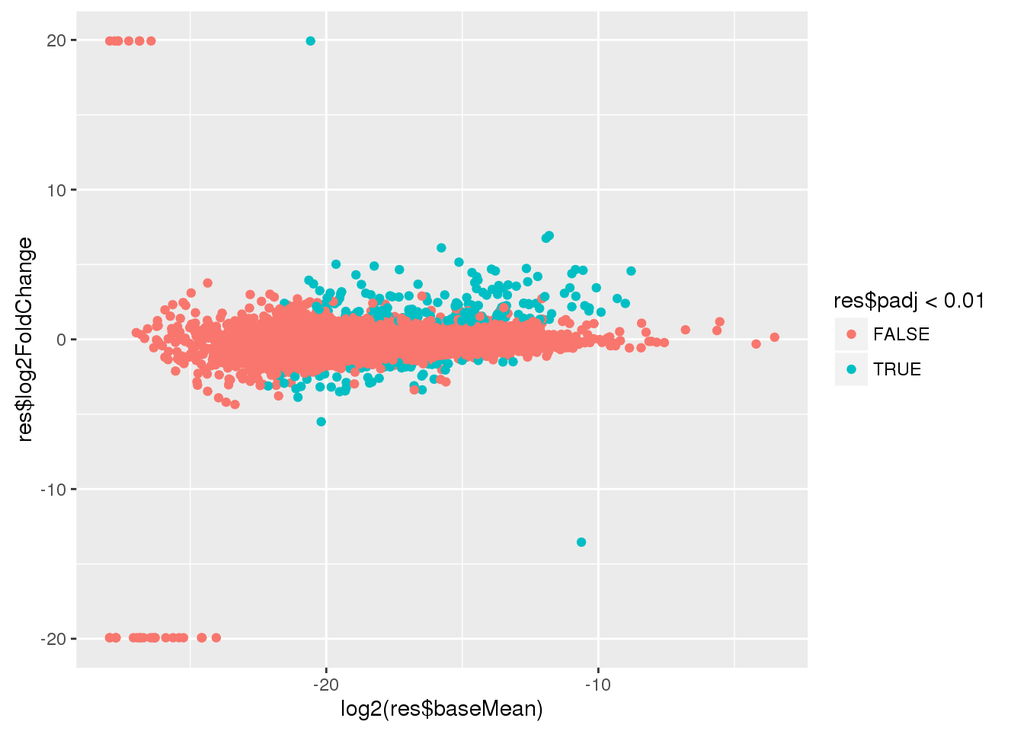

# Eucludian distances

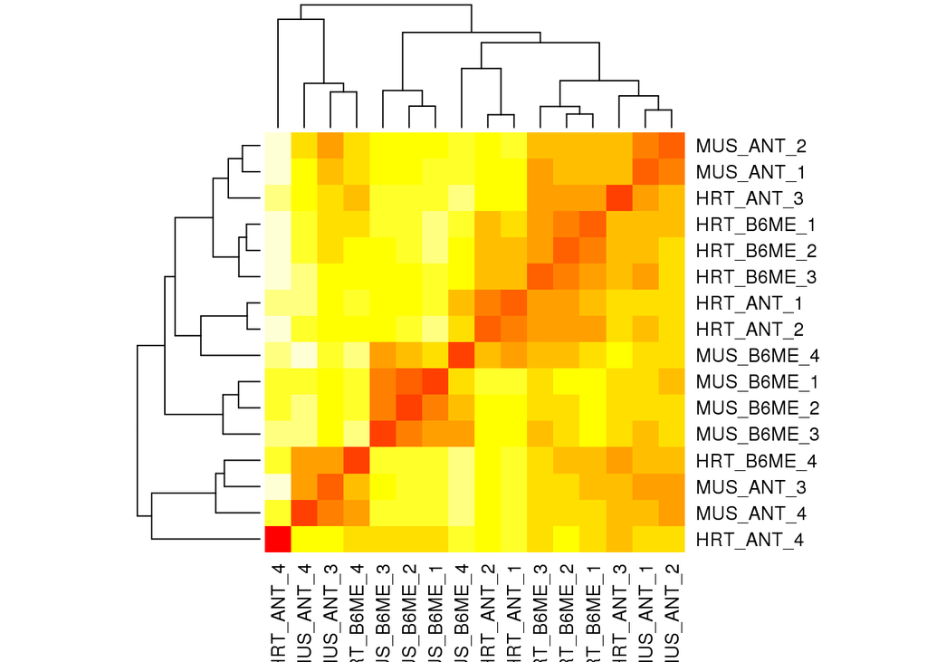

# Comparing Heart and Muscle

### Contingency table

Significantly differentially expressed genes after adjustment for multiple comparisons (padj<0.05). Heart is the left - muscle on the top.

| heart/muscle | Down | Unchanged | Up |
| --- | --- | --- | --- |
| Down | 66 | 33 | 0 |
| Unchanged | 2981 | 10286 | 1053 |
| Up | 0 | 167 | 46 |

### Proportion table: Significantly differentially expressed genes after adjustment for multiple comparisons (padj<0.05). Heart is the left - muscle on the top.

| heart/muscle | Down | Unchanged | Up |
| --- | --- | --- | --- |
| Down | 0.45 | 0.23 | 0.00 |
| Unchanged | 20.37 | 70.30 | 7.20 |
| Up | 0.00 | 1.14 | 0.31 |

### Upset Plot

All 9 intersections are shown in this innovative UpSet set visualization technique published by Lex, Gehlenborg, et al.

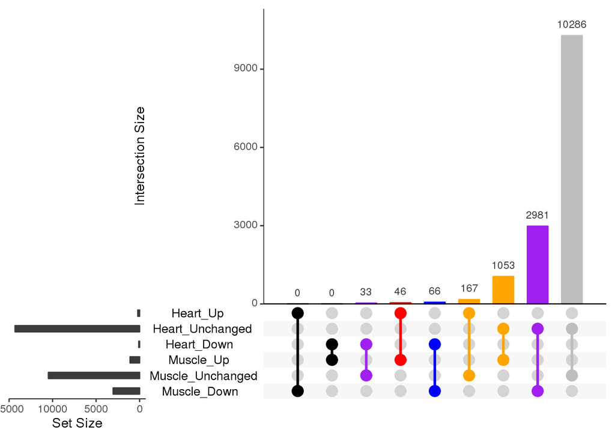

# Session info

```
## [1] "2016-02-19 17:07:49 EST"
```

Git Commit: 9658838a4493ed73ebe619660e2871a7ffb8a353